Real-to-sim for robotics

# Splats are not scenes

3D Gaussian Splatting is excellent at reproducing photographs of a place. A robot simulator needs something different: separable objects with surfaces, geometry, and appearance that holds up under new viewpoints and edits. This note explains why splats fall short on each of those, with examples from real splat reconstructions.

Yiming Chen · Nov 2026

01**Appearance is baked to the views**Colour is fitted with spherical harmonics per Gaussian, so lighting and reflections are frozen in and drift off the training views. 02**Objects have no clean boundary**Segmenting an object drags along clouds of low-opacity floaters and fuzzy edges. 03**Removal leaves holes**Deleting an object exposes unobserved space: smears, voids and leftover Gaussians. 04**No physics-ready geometry**There is no watertight surface, collision shape or reliable depth to simulate contact with.

## What real-to-sim actually needs

Gaussian Splatting represents a scene as millions of 3D Gaussians, each with a position, covariance, opacity and colour. They are optimised for one objective: rendered images should match the training photos. Nothing in that loss asks for a correct surface, a separable object, or physically meaningful colour.

A real-to-sim pipeline asks for all three. We want to pick a mug out of a reconstructed kitchen, give it a collision shape and mass, move it, render the scene from a wrist camera the capture never visited, and have the policy see something consistent with reality. Each step leans on a property that splats were never trained to have.

1

## Appearance depends on where you look

Each Gaussian's colour is not a single RGB value. It is a set of spherical-harmonic (SH) coefficients, usually up to degree 3 (48 numbers per Gaussian), evaluated against the viewing direction. This is how splats reproduce specular highlights and view-dependent shading. It also means:

For policy learning this matters directly. Visual observations that change with viewpoint in ways the real camera would not produce add a sim-to-real gap at exactly the point real-to-sim was meant to close.

2

## Segmented objects come with a cloud of noise

Object masks for splats are usually lifted from 2D (SAM-style masks projected onto Gaussians, or a learned per-Gaussian feature). Two things go wrong. Large, semi-transparent Gaussians straddle the object boundary and get assigned to one side or the other. And the optimiser leaves many **low-opacity floaters** that contribute almost nothing to any single training image but add up when the object is viewed in isolation.

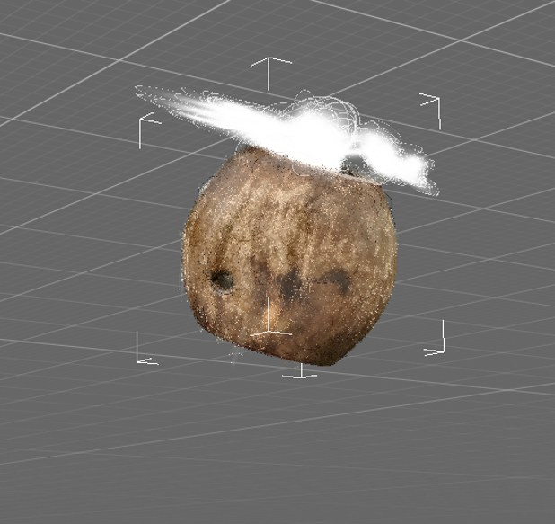

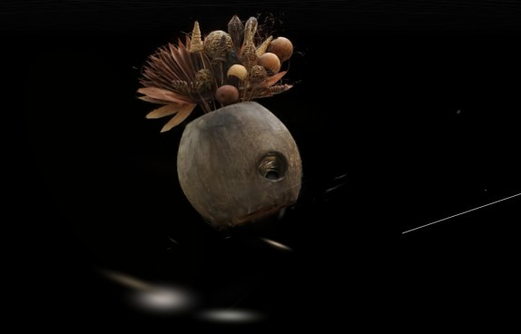

Fig. 1–2A coconut vase segmented out of its scene. Left: the selection includes a large white sheet of low-opacity Gaussians above the opening, left over from the dried flowers and background. Right: rendered on black, stray streaks and blobs float around the object and below it. These are invisible in the full scene and obvious once the object stands alone.

Raise the threshold and the object's soft outer layer disappears, leaving it shrunken and see-through at the rim. Lower it and the floaters stay. Clean-up then becomes manual, per object and per scene, which defeats the point of an automatic pipeline.

3

## Removing an object leaves a hole in the world

Real-to-sim usually needs the scene *without* the object too, so the object can be re-inserted as a simulated body. When we delete the object's Gaussians, the space behind and beneath it was never observed by the cameras. There is nothing there to render. What remains is a smeared, semi-transparent residue made of boundary Gaussians that belonged partly to the object and partly to the table.

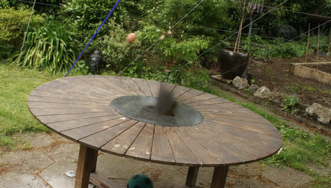

[figure not shown]

Fig. 3–4A garden table after removing the object at its centre, seen from two viewpoints. A dark ghost of the object remains above the turntable, and its shape changes between views because the leftover Gaussians are view-dependent too. The tabletop underneath was never seen, so there is no correct surface to show. In a sim, a robot camera would see this artefact and a depth sensor model would read it as an obstacle.

2D or 3D inpainting (for example diffusion-based fill) can paint over the gap, but the result is a plausible guess rather than a measurement, it is often inconsistent across views, and it has to be redone every time an object is moved.

4

## There is no geometry to simulate

Physics engines need meshes or primitives: watertight surfaces for collision, volumes for mass and inertia, normals for contact. A splat has none of these. Depth rendered from splats is an alpha-weighted average along each ray, which blurs edges and is pulled toward floaters. Mesh extraction methods (SuGaR, 2DGS, Gaussian Opacity Fields) help, but they add a second representation that no longer matches the rendered appearance, and they inherit the same floaters and holes shown above.

## Splats vs. what a simulator expects

| Requirement | Gaussian splat | Mesh + PBR material |
| --- | --- | --- |
| Novel-view photorealism | Excellent near capture path | Good with enough texture work |
| Robot-camera viewpoints | SH extrapolates, colours drift | Stable |
| Relighting | Lighting baked into SH | Supported by the renderer |
| Object segmentation | Floaters, fuzzy edges | Discrete parts |
| Object removal | Holes and ghosts | Needs background completion |
| Collision / contact | None without extraction | Native |
| Depth sensor simulation | Alpha-blended, noisy | Exact |

## Where splats still help

This is not an argument to drop splats entirely. They remain one of the fastest ways to get a photoreal backdrop from a phone video. The practical position is to keep them away from anything the robot touches:

- Use splats only for **static, distant background** that no camera approaches closely and nothing collides with.
- Represent **interactable objects as meshes** with collision shapes and PBR materials, reconstructed or scanned separately.
- If splats must be used near the robot, restrict SH to degree 0 or 1, prune low-opacity Gaussians, and capture extra views from robot-camera heights.
- Evaluate any splat-based sim on **held-out robot viewpoints**, not on the capture trajectory where it always looks good.

**Short version**Splats answer "what does this place look like from here?" Real-to-sim needs answers to "what is this object, where is its surface, and what happens when I move it?" Splats do not encode those.